# Week 9: Lab - Using aRules on the Titanic dataset

James Bressani

March 16, 2025

# Instructions

Use the Titanic dataset to explore descriptive statistics, functions, and association rules. Download the titanic dataset `titanic.raw.rdata` from one of two locations:

- https://github.com/ethen8181/machine-learning/tree/master/association_rule/R
- https://sites.google.com/a/rdatamining.com/www/data/titanic.raw.rdata?attredirects=1

Note that it is not a cvs file, but rather an RData workspace. So, to load the data (assuming you saved it to the project’s data folder), one would do:

`load("data/titanic.raw.rdata")`

You need to look at titanic.raw (the name of the R dataset)

`t <- titanic.raw`

Now that you have the datafile, do some descriptive statistics, getting some extra practice using R. Take the Quiz for Step 1 and 2. However your submission **MUST** include the process of you calculating the following values in Step 1 and 2.

```r
# Add your library below.
#install.packages('arules')
#install.packages('arulesViz')
library(arules)
library(arulesViz)
```

# Step 0 - Load the data

Using the instructions above, load the dataset and save it as `t`.

```r
# Write your code below.
t <- get(load("C:/Users/bress/Downloads/lastName_week9_Lab_v23 (2)/titanic.raw.rdata"))
head(t)
```

```
##   Class  Sex   Age Survived
## 1   3rd Male Child       No
## 2   3rd Male Child       No
## 3   3rd Male Child       No
## 4   3rd Male Child       No
## 5   3rd Male Child       No
## 6   3rd Male Child       No
```

# Step 1 - Descriptive stats

Important: Right next to your code, your answer should be written such as # 14% of children survived after rounding the 1 decimal place. For example, 1.36 is 2 1. Compute the percentage of people that survived. 2. Compute the percentage of people that were children. 3. Compute the percentage of people that were female. 4. Finally, compute the percentage of people that were in first class.

```r
# Write your code below.
survived <- mean(t$Survived == "Yes") #32% of the people survived
children <- mean(t$Age == "Child") #5% of the people were children
female <- mean(t$Sex == "Female") #21% of the people were women
firstclass <- mean(t$Class == "1st") #15% of the people were first class
```

# Step 2 - More descriptive stats

1. What percentage of children survived? Your answer should be written such as # 14% of children survived after rounding the 1 decimal place. For example, 1.36 is 2
2. What percentage of female survived?
3. What percentage of first-class people survived?
4. What percentage of third-class people survived?

```r
# Write your code below.
percentchildren <- mean(t$Survived[t$Age == "Child"] == "Yes") #53% of children survived
percentfemale <- mean(t$Survived[t$Sex == "Female"] == "Yes") #73% of females survived
percentfirst <- mean(t$Survived[t$Class == "1st"] == "Yes") #63% of the first class survived
percentthird <- mean(t$Survived[t$Class == "3rd"] == "Yes") #26% of the third class survived
```

# Step 3 - Writing a function

## Step 3.1 - Function 1

Write a function that returns a new dataframe of people that satisfies the specified criteria of sex, age, class and survived as parameters. I’m giving you the answer for this question:

```
myfunction1 <- function(a,b,c,d){
df1 <- t[t$Class == a,] # filter the data that satisfied the criteria that "Class" = a
df2 <- df1[df1$Sex == b,] # filter the data that satisfied the criteria that "Sex" = b
df3 <- df2[df2$Age == c,] # filter the data that satisfied the criteria that "Age" = c
df4 <- df3[df3$Survived == d,] # filter the data that satisfied the criteria that "Survived" = d
return(df4)}
# test the function with a sample data
myfunction1("1st","Female","Adult","No")
```

```r
# Write your code below.
myfunction1 <- function(a,b,c,d){
df1 <- t[t$Class == a,] # filter the data that satisfied the criteria that "Class" = a
df2 <- df1[df1$Sex == b,] # filter the data that satisfied the criteria that "Sex" = b
df3 <- df2[df2$Age == c,] # filter the data that satisfied the criteria that "Age" = c
df4 <- df3[df3$Survived == d,] # filter the data that satisfied the criteria that "Survived" = d
return(df4)}

head(myfunction1("1st","Female","Adult","No"))
```

```
##      Class    Sex   Age Survived
## 1382   1st Female Adult       No
## 1383   1st Female Adult       No
## 1384   1st Female Adult       No
## 1385   1st Female Adult       No
```

## Step 3.2 - Function 2

Write a function, using the previous function, that calculates the percentage (who lives, who dies) for specified (parameters) classes. The function passes four arguments. Calculating percentage means that the number of observations that meets the criteria (values of the specified classes) divided by the entire number of observations.

```r
# Write your code below.
#This function compares the percentage of people who survived with a specific classifications selected to others with the same classifications.
myfunction2 <- function(a, b, c, d){
  group <- myfunction1(a, b, c, d)
  totalGroup <- nrow(t[t$Class == a & t$Sex == b & t$Age == c, ])
  if (totalGroup == 0) {
    return(0)
  } else {
    return(nrow(group) / totalGroup * 100)
  }
}
myfunction2("1st", "Female", "Adult", "No")
```

```
## [1] 2.777778
```

```r
myfunction2("1st","Female","Child","Yes")
```

```
## [1] 100
```

```r
 # test the function with a sample data.
 # myfunction2("1st","Female","Adult","No")
```

## Step 3.3 - Use the function (male)

Use the function to compare age and third-class male survival rates.

```r
# Write your code below.
(thirdAge <- myfunction2("3rd", "Male", "Child", "Yes"))
```

```
## [1] 27.08333
```

```r
(thirdMale <- myfunction2("3rd", "Male", "Adult", "Yes"))
```

```
## [1] 16.23377
```

People in which category are more likely to survive?

> [Male children in third class were more likely to survive than third class men.]

## Step 3.4 - Use the function (female)

Use the function to compare age and first-class female survival rates.

```r
# Write your code below.
(firstAge <- myfunction2("1st", "Female", "Child", "Yes"))
```

```
## [1] 100
```

```r
(firstFemale <- myfunction2("1st", "Female", "Adult", "Yes"))
```

```
## [1] 97.22222
```

People in which category are more likely to survive?

> [The first class female children were more likely to survive than first class adult women.]

# Step 4 - Use aRules

1. Use aRules to calculate some rules (clusters) for the titanic dataset. set support threshold as 0.005, and confidence as 0.5. Show only rhs=(“Survived=Yes”). Read the documentation to investigate “appearance”
2. Visualize the results.
3. Pick the three most interesting and useful rules (a. pick rules whose lift is higher than 2, b. sort the good rules by “lift”). Explain these rules using natural language. **Answer this in the space provided below.**
4. How does this compare to the descriptive analysis we did on the same data set? Think critically. What was possible using one method that was not possible using the other method? **Answer this in the space provided below.**

```r
# Write your code below.
tTrans <- as(t, "transactions")

rules <- apriori(tTrans,
                 parameter = list(support = 0.005, confidence = 0.5),
                 appearance = list(rhs = c("Survived=Yes"), default="lhs"))
```

[output not shown]

```r
Sorted <- sort(rules, by="lift", decreasing=TRUE)
inspect(Sorted[1:10])
```

```
##      lhs                                    rhs            support
## [1]  {Class=2nd, Age=Child}              => {Survived=Yes} 0.010904134
## [2]  {Class=2nd, Sex=Female, Age=Child}  => {Survived=Yes} 0.005906406
## [3]  {Class=1st, Sex=Female}             => {Survived=Yes} 0.064061790
## [4]  {Class=1st, Sex=Female, Age=Adult}  => {Survived=Yes} 0.063607451
## [5]  {Class=2nd, Sex=Female}             => {Survived=Yes} 0.042253521
## [6]  {Class=Crew, Sex=Female}            => {Survived=Yes} 0.009086779
## [7]  {Class=Crew, Sex=Female, Age=Adult} => {Survived=Yes} 0.009086779
## [8]  {Class=2nd, Sex=Female, Age=Adult}  => {Survived=Yes} 0.036347115
## [9]  {Sex=Female, Age=Adult}             => {Survived=Yes} 0.143571104
## [10] {Sex=Female}                        => {Survived=Yes} 0.156292594
##      confidence coverage    lift     count
## [1]  1.0000000  0.010904134 3.095640  24
## [2]  1.0000000  0.005906406 3.095640  13
## [3]  0.9724138  0.065879146 3.010243 141
## [4]  0.9722222  0.065424807 3.009650 140
## [5]  0.8773585  0.048159927 2.715986  93
## [6]  0.8695652  0.010449796 2.691861  20
## [7]  0.8695652  0.010449796 2.691861  20
## [8]  0.8602151  0.042253521 2.662916  80
## [9]  0.7435294  0.193094048 2.301699 316
## [10] 0.7319149  0.213539300 2.265745 344
```

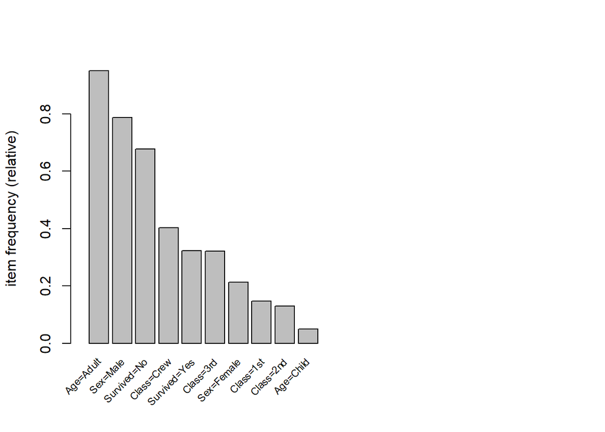

```r
itemFrequencyPlot(tTrans, support = 0.005, cex.names=0.7, topN=20)
```

```r
highLiftRules <- subset(Sorted, lift > 2)
inspect(highLiftRules[1:3])
```

```
##     lhs                                   rhs            support     confidence
## [1] {Class=2nd, Age=Child}             => {Survived=Yes} 0.010904134 1.0000000
## [2] {Class=2nd, Sex=Female, Age=Child} => {Survived=Yes} 0.005906406 1.0000000
## [3] {Class=1st, Sex=Female}            => {Survived=Yes} 0.064061790 0.9724138
##     coverage    lift     count
## [1] 0.010904134 3.095640  24
## [2] 0.005906406 3.095640  13
## [3] 0.065879146 3.010243 141
```

**Answer part 3 and 4 below.**

> [3. I thought the most interesting rule was that every child in 2nd class survived, most would certainly think that first class was prioritized, Another interesting rule was that female crew members had a high survival rate. This survival rate was 86.9%. The third rule I found interesting was that over 73% of females survived the titanic crash. 4.Descriptive analysis focuses more on specific classifications. The functions made could choose certain details and find a statistic based on what we chose. Association rules uses an algorithm to identify relationships we may not have thought of, such as the diapers and beer in the textbook. Association rules found out that 100% of 2nd class children survived, and one may not have thought to look into that. ]